# mplot: An R Package for Graphical Model Stability and Variable Selection Procedures

### Katarzyna Woźnica

## Plan prezentacji

1. Krótkie przedstawienie problemu stabilności wyboru zmienych
2. Przedstawienie i omówienie funkcji pakietu mplot
3. Przykład

## Wstęp do problemu

Mamy $n$ niezależnych obserwacji $y = (y_1, . . . , y_n)$, a $X \in R^{n \times p} $ jest macierzą eksperymetu pełnego rzędu.

Niech $\alpha$ oznacza zbiór indeksów ze zbioru $\{1, . . . , p\}$. Macierz $X_\alpha$ jest macierzą odpowiadającą kolumnom macierzy $X$ z indeksami ze zbioru $\alpha$.

**Głównym celem jest znalezienie najlepszych podzbiorow indeksów $\alpha$ (inaczej aktywnych predyktorów) i odpowiadających im modeli, najlepiej pasujących do danych.**

Chcemy znaleźć model, który minimalizuje funkcję straty: $$ GIC( \alpha, \lambda) = \hat{Q}(\alpha) + \lambda p_{\alpha}$$ $\hat{Q}(\alpha)$ - jest miarą dopasowania do danych np. MSE, - logarytm funkcji wiarogodności

$p_{\alpha}$ - liczba zmiennych w modelu

$\lambda$ - parametr

W takiej formie możemy przedstawić np. AIC, BIC.

Na początku rozważmy sztuczny przykład, w którym wiemy jaka jest zależność miedzy zmienną odpowiedzi a zmiennymi objaśniającymi. Przykład ten został wbudowany w bibliotekę `mplot`. Prawdziwa zależność ma postać $$ y = 0.6 x_8 + \varepsilon, $$ gdzie $\varepsilon \sim \mathcal{N}(0,4)$.

Zmienne $x_1, ..., x _9$ są niezależne i mają rozkład normalny.

```r
library('mplot')
```

```r
data("artificialeg", package = "mplot")
(head(artificialeg))
```

| x1 | x2 | x3 | x4 | x5 | x6 | x7 | x8 | x9 | y |
| --- | --- | --- | --- | --- | --- | --- | --- | --- | --- |
| 0.1 | -3.1 | -0.6 | 2.4 | -0.2 | 0.9 | 2.2 | -7.9 | -1.4 | -5.5 |
| 1.9 | -3.2 | 1.9 | -1.4 | -2.5 | -7.1 | 0.2 | 4.5 | -0.2 | 5.3 |
| -0.7 | 0.2 | 2.2 | -1.6 | -4.2 | -4.4 | 0.8 | 2.9 | 4.8 | 2.1 |
| -0.9 | -2.9 | 2.4 | -2.6 | 4.5 | -4.7 | -0.6 | 0.1 | -4.2 | 1.7 |
| 1.7 | -3.2 | -0.6 | -0.5 | -1.0 | -1.2 | 2.8 | -0.8 | 0.5 | -3.3 |
| 0.0 | 2.0 | 0.9 | 3.8 | -2.5 | -1.5 | 1.2 | 1.4 | 3.7 | -4.8 |

## Stabilność modelu i wyboru zmiennych

1. funkcja `vis`

   Argumenty tej funkcji:
   - B - ilość prób bootstrap
   - redundant - dodanie nowej, niezależnej zmiennej
   - nbest - ilość zapamiętanych najlepszych modeli

```r
lm.art <- lm(y ~ ., data = artificialeg)
vis.art <- vis(lm.art, B = 150, redundant = TRUE, nbest = "all", seed = 2017)
```

### Funkcje do wizualizacji

1. Przeciążona funkcja `plot`

   Najważniejsze argumenty:
   - `x` - obiekt typy `vis`
   - `hightlight` - nazwa zmiennej
   - `which` - typ wykresu

### which = 'lvk'

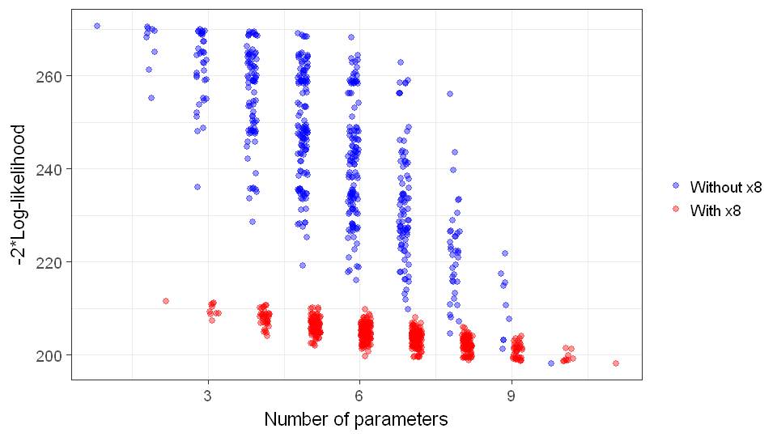

```r
library(repr)
options(repr.plot.width = 8, repr.plot.height = 4.5)
plot(vis.art, highlight = "x8", which = "lvk")
```

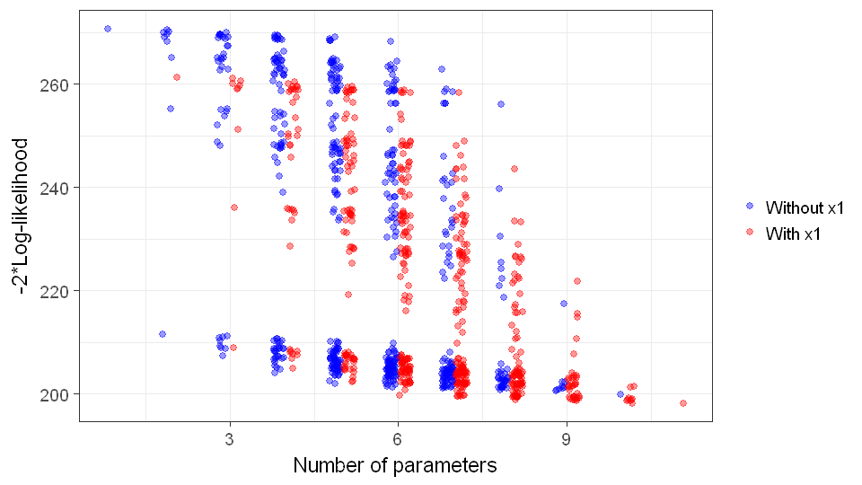

```r
options(repr.plot.width = 8, repr.plot.height = 4.5)
plot(vis.art, highlight = "x1", which = "lvk")
```

### which = 'boot'

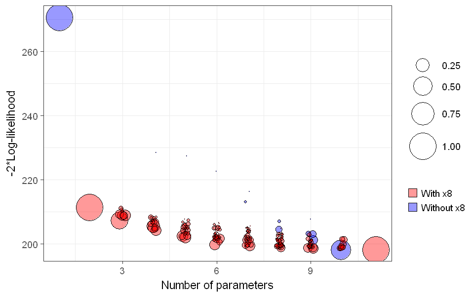

```r
options(repr.plot.width = 8, repr.plot.height = 5)
plot(vis.art, highlight = "x8", which = "boot")
```

```r
print(vis.art, min.prob = 0.25)
```

```
                         name prob logLikelihood
                          y~1 1.00       -135.33
                         y~x8 1.00       -105.72
                      y~x4+x8 0.44       -103.63
 y~x1+x2+x3+x4+x5+x6+x7+x9+RV 0.55        -99.09
```

### which ='vip'

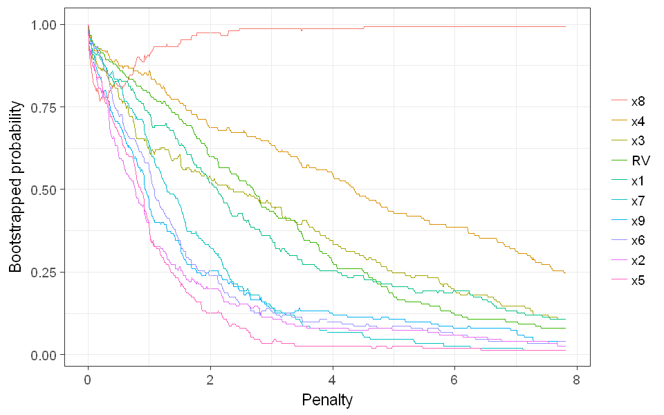

```r
options(repr.plot.width = 8, repr.plot.height = 5)
plot(vis.art, highlight = "x8", which = "vip")
```

## Adaptive fence

Dla każdej próby bootstrap i ustalonego parametru $c$ rozważamy modele $\alpha$ spełniające nierówność $$ \hat{Q}(\alpha) - \hat{Q}(\alpha_f) <c, $$ gdzie $\alpha_f$ jest modelem pełnym.

Spośród tych modeli wybieramy ten o najmniejszej liczbie predyktorów. Następnie spośród wszystkich prób bootstrap wybieramy ten model, który był wybierany najczęściej.

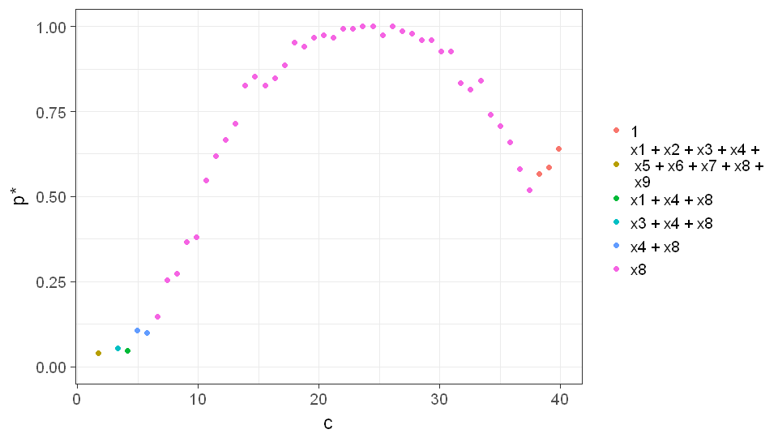

```r
options(repr.plot.width = 8, repr.plot.height = 4.5)

af.art <- af(lm.art, B = 150, n.c = 50, seed = 2017)
plot(af.art, best.only = TRUE, legend.position = "right", model.wrap = 4)
```

# Interactive Example

```r
mplot(lm.art, vis.art, af.art)
```